# Lab 1 Graphing Data (Part 1)

B. Sosnovski

10/04/2021

# Lab 1 Graphing Data (Part 1)

When we measure things, we get lots of numbers. Sometimes so many your head explodes just thinking about them. One of **the most helpful things** you can do to begin to make sense of these numbers, is to look at them in graphical form.

## General Goals

Our general goals for this first part of lab 1 are to do the following:

1. Load in some data to R
2. See a little bit of how the data is structured
3. Make graphs of the data so we can look at it and make sense of it.

### Important info

Data for NYC film permits was obtained from the NYC open data website. The Film_Permits.csv file for this lab is already in the folder for this lab. But you can also find it here: [Film_Permits.csv](https://data.cityofnewyork.us/api/views/tg4x-b46p/rows.csv?accessType=DOWNLOAD)

## R

### Lab templates

You will be completing each lab by writing your code and notes in an R Markdown document.

Open the answer template Rmd file for lab 1 (Part 1). Use it to begin adding your code and notes for lab 1.

### Installing a R package

#### Installing when you are using Cocalc’s free trial (free version)

If you are running your project on a free server, watch this screencast to help you install a R package.

[video not shown]

#### Installing with a license for your project (paid version)

If you are running your project on a paid server, watch this screencast to help you install a R package in Cocalc.

[video not shown]

### More resources for leaning R

There are numerous resources for learning about R, you will find some of them available on this webpage: [resouces page](https://crumplab.github.io/psyc3400/Resources.html).

It is not required for any of the MA336 Labs but if you are interested in downloading and installing R and R Studio at home (it’s free) to your own computer, you can check how to here: [general introduction to R and Rstudio](https://crumplab.github.io/statisticsLab/software.html#r).

### Get some data

In order to graph data, we need to have some data first… Actually, with R, that’s not quite true. Run this bit of code and see what happens:

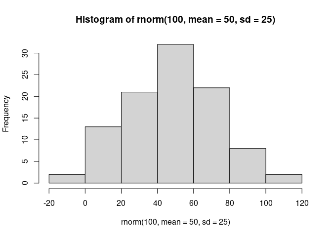

```r
hist(rnorm(100, mean=50, sd=25))
```

You just made R sample 100 numbers, and then plot the results in a histogram (we will study later in the course what type of distribution this is, which called a normal distribution).

For now, let’s do something that might be a little bit more interesting… what movies are going to be filming in NYC? It turns out that NYC makes a lot of data about a lot things open and free for anyone to download and look at. This is the NYC Open Data website: https://opendata.cityofnewyork.us.

Searching through the data we can find a data file that lists the locations of film permits for shooting movies all throughout NYC’s five boroughs. There are multiple ways to load this data into R.

Conveniently you have this data set available to you in the same folder as your lab 1 part 1, so you don’t have to download the data file to your computer and upload here.

Then use the following commands to load the data.

```r
library(data.table)
nyc_films <-fread("Film_Permits.csv")
```

If the above method doesn’t work, you can try loading the data from the lab manual website using:

```r
library(data.table)
nyc_films <- fread("https://data.cityofnewyork.us/api/views/tg4x-b46p/rows.csv?accessType=DOWNLOAD")
```

**Note:** The code above will not be evaluate in R because of the option `eval` is set to `FALSE`.

### Look at the data

You will be downloading and analyzing all kinds of data files this semester. We will follow the very same steps every time. The steps are to load the data, then look at it. You want to see what you’ve got.

The data above is stored in something we call a `data frame`. It’s R lingo, for the thing that contains the data, with rows going across, and columns going up and down. It looks kind of like an excel spreadsheet if you are familiar with Excel.

Let’s take a look at the size of this data set (data frame).

```r
data_size <- dim(nyc_films)
data_size
```

```
## [1] 70989    14
```

It’s useful to know you can look at the data frame itself if you need to. But, this data frame is really big, it has 70989 rows and 14 columns of data. That’s a lot too much to look at.

In R, we examine what is in a data frame using different functions. Here some examples: `View()`, `head()`, `tail()`, `str()`, and `colnames()`.

```r
colnames(nyc_films)
```

```
##  [1] "EventID"           "EventType"         "StartDateTime"
##  [4] "EndDateTime"       "EnteredOn"         "EventAgency"
##  [7] "ParkingHeld"       "Borough"           "CommunityBoard(s)"
## [10] "PolicePrecinct(s)" "Category"          "SubCategoryName"
## [13] "Country"           "ZipCode(s)"
```

```r
head(nyc_films)
```

```
##    EventID                     EventType          StartDateTime
## 1:  446040               Shooting Permit 10/19/2018 02:00:00 PM
## 2:  446168               Shooting Permit 10/19/2018 02:00:00 PM
## 3:  186438               Shooting Permit 10/30/2014 07:00:00 AM
## 4:  445255               Shooting Permit 10/20/2018 07:00:00 AM
## 5:  128794 Theater Load in and Load Outs 11/16/2013 12:01:00 AM
## 6:   43547               Shooting Permit 01/10/2012 07:00:00 AM
##               EndDateTime              EnteredOn
## 1: 10/20/2018 04:00:00 AM 10/16/2018 11:57:27 AM
## 2: 10/20/2018 02:00:00 AM 10/16/2018 07:03:56 PM
## 3: 10/31/2014 02:00:00 AM 10/27/2014 12:14:15 PM
## 4: 10/20/2018 06:00:00 PM 10/09/2018 09:34:58 PM
## 5: 11/17/2013 06:00:00 AM 11/07/2013 03:48:28 PM
## 6: 01/10/2012 07:00:00 PM 01/04/2012 12:25:37 PM
##                                       EventAgency
```

[output cut: 27 more lines]

#### summarytools package

The summarytools package gives a quick way to summarize all of the data in a data frame.

```r
library(summarytools)
view(dfSummary(nyc_films))
```

### Make Plots to answer questions

Let’s walk through a couple questions we might have about this data.

We can see that there were 70989 film permits made. We can also see that there are different columns telling us information about each of the film permits. For example, the `Borough` column lists the Borough for each request, whether it was made for: Manhattan, Brooklyn, Bronx, Queen’s, or Staten Island. Now we can ask our first question, and learn how to do some plotting in R.

#### Where are the most film permits being requested?

In which of the five boroughs of NYC, film permits being requested? Is it Manhattan, or Brooklyn, of the Bronx? Or Queens or Staten Island?

We can find out by plotting the data using a bar plot. We just need to count how many film permits are made in each borough, and then make different bars represent the the counts.

First, we do the counting in R. Run the following code.

```r
library(dplyr)
counts <- nyc_films %>%
          group_by(Borough) %>%
          summarize(count_of_permits = length(Borough))
```

The above grouped the data by each of the five boroughs, and then counted the number of times each Borough occurred (using the `length` function). The result is a new variable called `counts`.

We do the plot using a fantastic package called `ggplot2`. It is very powerful once you get the hand of it, and when you do, you will be able to make all sorts of interesting graphs. Here’s the code to make the plot

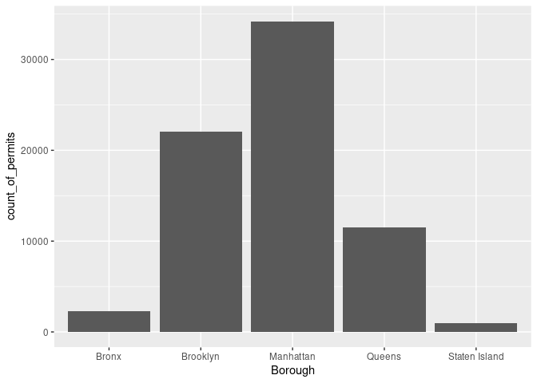

```r
library(ggplot2)

ggplot(counts, aes(x = Borough, y = count_of_permits )) +
  geom_bar(stat="identity")
```

We can easily look at this graph, and answer our question. Most of the film permits were requested in Manhattan, followed by Brooklyn, then Queens, the Bronx, and finally Staten Island.

#### What kind of “films” are being made, what is the category?

We think you might be skeptical of what you are doing here, copying and pasting things. Soon you’ll see just how fast you can do things by copying and pasting, and make a few little changes.

Let’s quickly ask another question about what kinds of films are being made. The column `Category`, gives us some information about that. Let’s just copy paste the code we already made, and see what kinds of categories the films fall into. See if you can tell what I changed in the code to make this work, I’ll do it all at once:

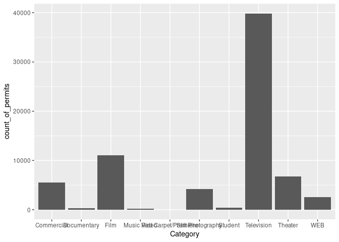

```r
counts <- nyc_films %>%
          group_by(Category) %>%
          summarize(count_of_permits = length(Category))

ggplot(counts, aes(x = Category, y = count_of_permits )) +
  geom_bar(stat="identity")
```

OK, so this figure might look a bit weird because the labels on the bottom are running into each other. We’ll fix that in a bit. First, let’s notice the changes.

1. `Borough` was changed to `Category`. That was the main thing
2. Note that none of the `library()` commands are used again, and I didn’t re-run the very early code to get the data. R already has those things in it’s memory, so we don’t need to do that first. If you ever clear the memory of R, then you will need to reload those things.

Fine, so how do we fix the graph? Good question. One way to find out is to search using Google.

The googling of your questions is a fine way to learn R. It’s what everybody does these days….[goes to Google…].

The trick is to add the last line to the code. I just copy-pasted it from the solution I found on [stack overflow](https://stackoverflow.com/questions/1330989/rotating-and-spacing-axis-labels-in-ggplot2) (I hope you will become friend’s with stack overflow, there are many solutions there to all of your questions)

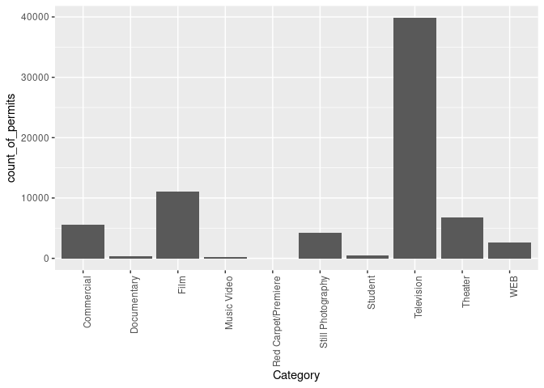

```r
counts <- nyc_films %>%
          group_by(Category) %>%
          summarize(count_of_permits = length(Category))

ggplot(counts, aes(x = Category, y = count_of_permits )) +
  geom_bar(stat="identity")+
  theme(axis.text.x = element_text(angle = 90, hjust = 1))
```

### ggplot2 basics

Before we go further, let’s check some basic properties of ggplot2, just to give you a sense of how it is working. This will make more sense later with other labs, so come back here to remind yourself.

We’ll do just a bit a basics, and then move on to making more graphs, by copying and pasting.

The ggplot function uses layers. What are these layers? Well, it draws things from the bottom up. It lays down one layer of graphics, then you can keep adding on top, drawing more things. So the idea is something like: Layer 1 + Layer 2 + Layer 3, and so on. If you want Layer 3 to be Layer 2, then you just switch them in the code.

Here is a way of thinking about ggplot code

```
ggplot(name_of_data, aes(x = name_of_x_variable, y = name_of_y_variable)) +
    geom_layer()+
    geom_layer()+
    geom_layer()
```

What I want you to focus on in the above description is the $+$ signs. What we are doing with the plus signs is adding layers to plot. The layers get added in the order that they are written. If you look back to our previous code, you will see we add a `geom_bar` layer, then we added another layer to change the rotation of the words on the x-axis. This is how it works.

BUT WAIT? How am I supposed to know what to add? This is nuts! We know. You’re not supposed to know just yet, how could you? We’ll give you lots of examples where you can copy and paste, and they will work. That’s how you’ll learn. If you really want to read the [help manual](https://ggplot2.tidyverse.org/reference/index.html) you can do that too. It’s on the ggplot2 website. This will become useful after you already know what you are doing, before that, it will probably just seem very confusing. However, it is pretty neat to look and [see all of the different things you can do](http://www.ggplot2-exts.org/gallery/), it’s very powerful.

For now, let’s get the hang of adding things to the graph that let us change some stuff we might want to change. For example, how do you add a title? Or change the labels on the axes? Or add different colors, or change the font-size, or change the background? You can change all of these things by adding different lines to the existing code.

#### ylab() changes y label

The last graph had `count_of_permits` as the label on the y-axis. That doesn’t look right. ggplot2 automatically took the label from the column, and made it be the name on the y-axis. We can change that by adding `ylab("what we want")`. We do this by adding a $+$ to the last line, then adding `ylab()`

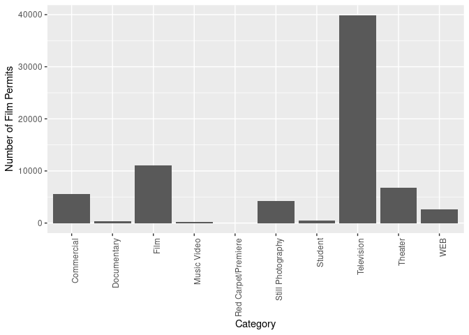

```r
ggplot(counts, aes(x = Category, y = count_of_permits )) +
  geom_bar(stat="identity") +
  theme(axis.text.x = element_text(angle = 90, hjust = 1)) +
  ylab("Number of Film Permits")
```

#### xlab() changes x label

Let’s slightly modify the x label too:

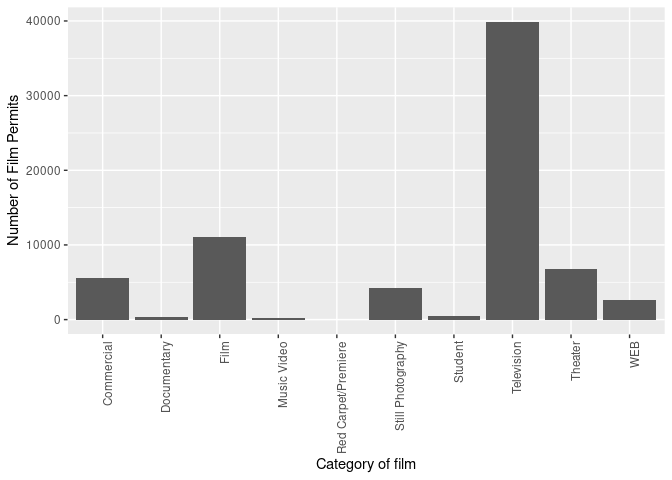

```r
ggplot(counts, aes(x = Category, y = count_of_permits )) +
  geom_bar(stat="identity") +
  theme(axis.text.x = element_text(angle = 90, hjust = 1)) +
  ylab("Number of Film Permits") +
  xlab("Category of film")
```

#### ggtitle() adds title

Let’s give our graph a title

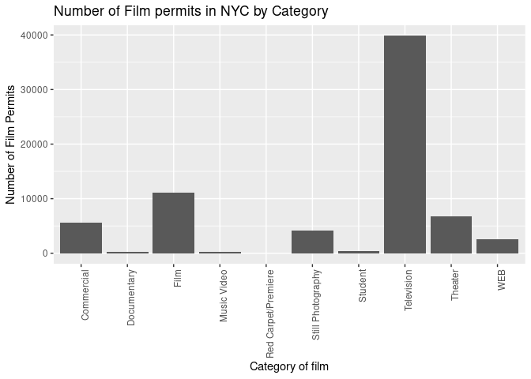

```r
ggplot(counts, aes(x = Category, y = count_of_permits )) +
  geom_bar(stat="identity") +
  theme(axis.text.x = element_text(angle = 90, hjust = 1)) +
  ylab("Number of Film Permits") +
  xlab("Category of film") +
  ggtitle("Number of Film permits in NYC by Category")
```

#### color adds color

Let’s make the bars different colors. To do this, we add new code to the inside of the `aes()` part:

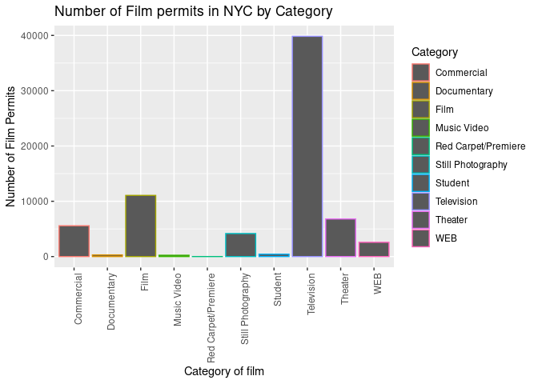

```r
ggplot(counts, aes(x = Category, y = count_of_permits, color=Category )) +
  geom_bar(stat="identity") +
  theme(axis.text.x = element_text(angle = 90, hjust = 1)) +
  ylab("Number of Film Permits") +
  xlab("Category of film") +
  ggtitle("Number of Film permits in NYC by Category")
```

#### fill fills in color

Let’s make the bars different colors. To do this, we add new code to the inside of the `aes()` part…Notice I’ve started using new lines to make the code more readable.

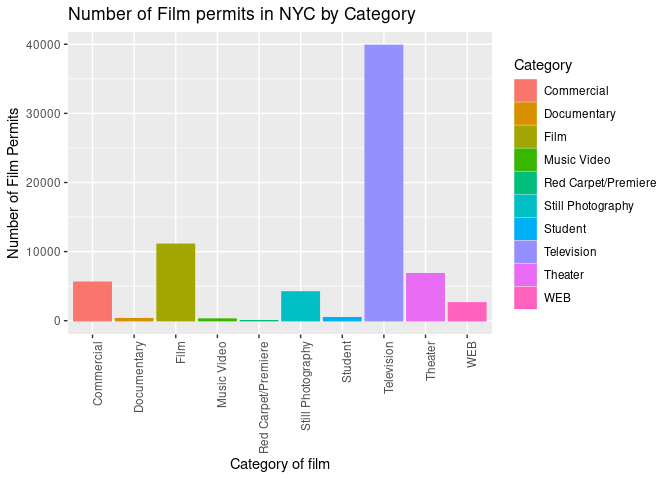

```r
ggplot(counts, aes(x = Category, y = count_of_permits,
                   color=Category,
                   fill= Category )) +
  geom_bar(stat="identity") +
  theme(axis.text.x = element_text(angle = 90, hjust = 1)) +
  ylab("Number of Film Permits") +
  xlab("Category of film") +
  ggtitle("Number of Film permits in NYC by Category")
```

#### Modifiy or get rid of the legend

If we want to move the legend to appear below the graph we can add

`theme(legend.position="bottom")`

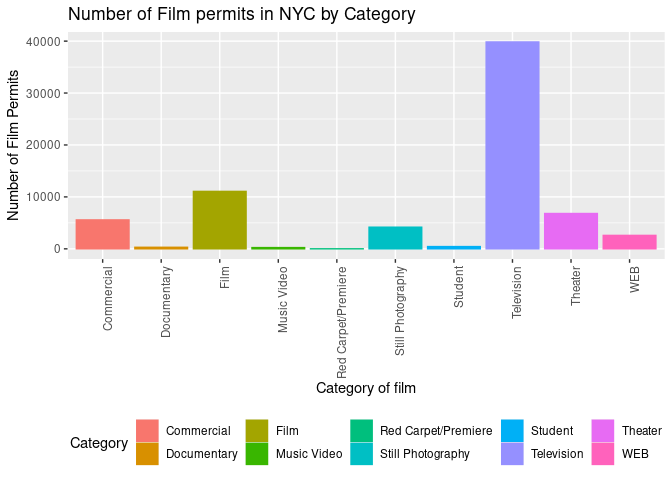

```r
ggplot(counts, aes(x = Category, y = count_of_permits,
                   color=Category,
                   fill= Category )) +
  geom_bar(stat="identity") +
  theme(axis.text.x = element_text(angle = 90, hjust = 1)) +
  ylab("Number of Film Permits") +
  xlab("Category of film") +
  ggtitle("Number of Film permits in NYC by Category") +
  theme(legend.position="bottom")
```

Sometimes you just don’t want the legend on the side, to remove it add

`theme(legend.position="none")`

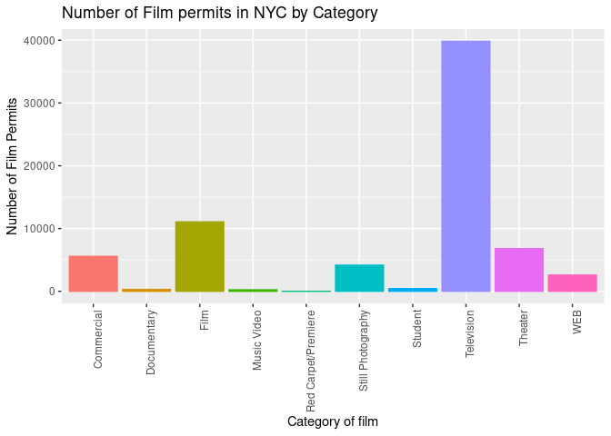

```r
ggplot(counts, aes(x = Category, y = count_of_permits,
                   color=Category,
                   fill= Category )) +
  geom_bar(stat="identity") +
  theme(axis.text.x = element_text(angle = 90, hjust = 1)) +
  ylab("Number of Film Permits") +
  xlab("Category of film") +
  ggtitle("Number of Film permits in NYC by Category") +
  theme(legend.position="none")
```

#### theme_classic() makes white background

The rest is often just visual preference. For example, the graph above has this grey grid behind the bars. For a clean classic no nonsense look, use `theme_classic()` to take away the grid.

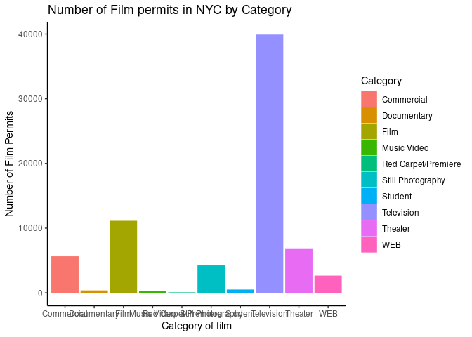

```r
ggplot(counts, aes(x = Category, y = count_of_permits,
                   color=Category,
                   fill= Category )) +
  geom_bar(stat="identity") +
  theme(axis.text.x = element_text(angle = 90, hjust = 1)) +
  ylab("Number of Film Permits") +
  xlab("Category of film") +
  ggtitle("Number of Film permits in NYC by Category") +
  theme(legend.position="none") +
  theme_classic()
```

#### Sometimes layer order matters

Interesting, `theme_classic()` is misbehaving a little bit. It looks like we have some of our layer out of order, let’s re-order. I just moved `theme_classic()` to just underneath the `geom_bar()` line. Now everything get’s drawn properly.

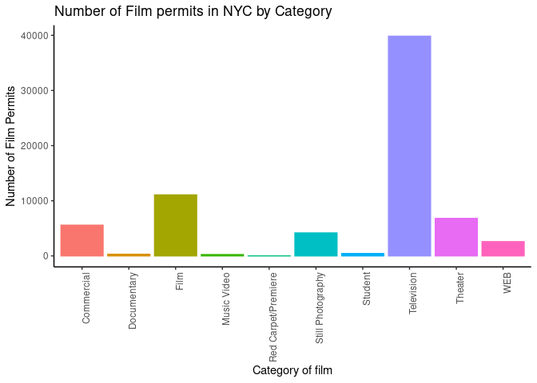

```r
ggplot(counts, aes(x = Category, y = count_of_permits,
                   color=Category,
                   fill= Category )) +
  geom_bar(stat="identity") +
  theme_classic() +
  theme(axis.text.x = element_text(angle = 90, hjust = 1)) +
  ylab("Number of Film Permits") +
  xlab("Category of film") +
  ggtitle("Number of Film permits in NYC by Category") +
  theme(legend.position="none")
```

#### Font-size

Changing font-size is often something you want to do. ggplot2 can do this in different ways. I suggest using the `base_size` option inside `theme_classic()`. You set one number for the largest font size in the graph, and everything else gets scaled to fit with that that first number. It’s really convenient. Look for the inside of `theme_classic()`

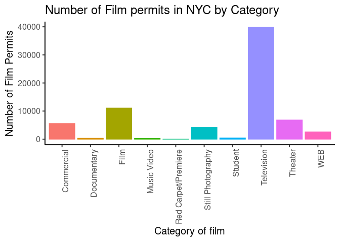

```r
ggplot(counts, aes(x = Category, y = count_of_permits,
                   color=Category,
                   fill= Category )) +
  geom_bar(stat="identity") +
  theme_classic(base_size = 15) +
  theme(axis.text.x = element_text(angle = 90, hjust = 1)) +
  ylab("Number of Film Permits") +
  xlab("Category of film") +
  ggtitle("Number of Film permits in NYC by Category") +
  theme(legend.position="none")
```

or make things small… just to see what happens

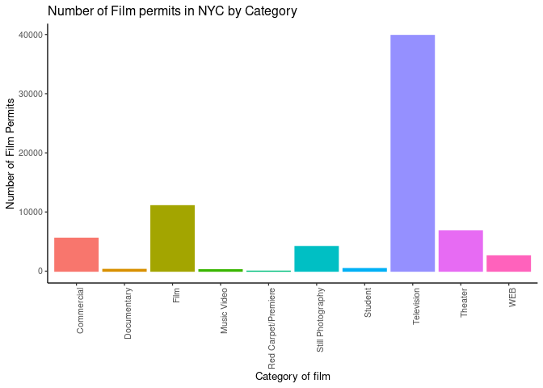

```r
ggplot(counts, aes(x = Category, y = count_of_permits,
                   color=Category,
                   fill= Category )) +
  geom_bar(stat="identity") +
  theme_classic(base_size = 10) +
  theme(axis.text.x = element_text(angle = 90, hjust = 1)) +
  ylab("Number of Film Permits") +
  xlab("Category of film") +
  ggtitle("Number of Film permits in NYC by Category") +
  theme(legend.position="none")
```

#### ggplot2 summary

That’s enough of the ggplot2 basics for now. You will discover that many things are possible with ggplot2. It is amazing. We are going to get back to answering some questions about the data with graphs. But, now that we have built the code to make the graphs, all we need to do is copy-paste, and make a few small changes, and boom, we have our graph.

### More questions about NYC films

#### What are the sub-categories of films?

Notice the `nyc_films` data frame also has a column for `SubCategoryName`. Let’s see what’s going on there with a quick plot.

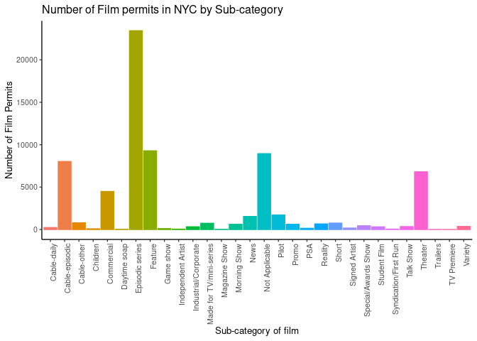

```r
# get the counts (this is a comment it's just here for you to read)

counts <- nyc_films %>%
          group_by(SubCategoryName) %>%
          summarize(count_of_permits = length(SubCategoryName))

# make the plot

ggplot(counts, aes(x = SubCategoryName, y = count_of_permits,
                   color=SubCategoryName,
                   fill= SubCategoryName )) +
  geom_bar(stat="identity") +
  theme_classic(base_size = 10) +
  theme(axis.text.x = element_text(angle = 90, hjust = 1)) +
  ylab("Number of Film Permits") +
  xlab("Sub-category of film") +
  ggtitle("Number of Film permits in NYC by Sub-category") +
  theme(legend.position="none")
```

I guess “episodic series” are the most common. Using a graph like this gave us our answer super fast.

#### Categories by different Boroughs

Let’s see one more really useful thing about ggplot2. It’s called `facet_wrap()`. It’s an ugly word, but you will see that it is very cool, and you can do next-level-super-hero graph styles with `facet_wrap` that other people can’t do very easily.

Here’s our question. We know that some films are made in different Boroughs, and that same films are made in different categories, but do different Boroughs have different patterns for the kinds of categories of films they request permits for? Are there more TV shows in Brooklyn? How do we find out? Watch, just like this:

```r
# get the counts (this is a comment it's just here for you to read)

counts <- nyc_films %>%
          group_by(Borough,Category) %>%
          summarize(count_of_permits = length(Category))
```

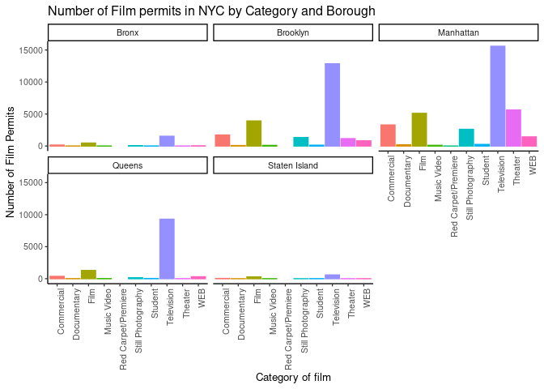

```r
# make the plot

ggplot(counts, aes(x = Category, y = count_of_permits,
                   color=Category,
                   fill= Category )) +
  geom_bar(stat="identity") +
  theme_classic(base_size = 10) +
  theme(axis.text.x = element_text(angle = 90, hjust = 1)) +
  ylab("Number of Film Permits") +
  xlab("Category of film") +
  ggtitle("Number of Film permits in NYC by Category and Borough") +
  theme(legend.position="none") +
  facet_wrap(~Borough, ncol=3)
```

We did two important things. First we added `Borough` and `Category` into the `group_by()` function. This automatically gives separate counts for each category of film, for each Borough. Then we added `facet_wrap(~Borough, ncol=3)` to the end of the plot, and it automatically drew us 5 different bar graphs, one for each Borough! That was fast. Imagine doing that by hand.

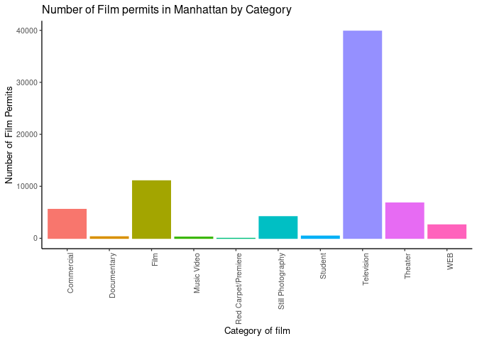

```r
# get the counts of categories for Manhattan (this is a comment it's just here for you to read)

counts <- nyc_films %>%
          group_by(Category) %>%
          filter(any(Borough=='Manhattan'))%>%
          summarize(count_of_permits = length(Category))

# make the plot

ggplot(counts, aes(x = Category, y = count_of_permits,
                   color=Category,
                   fill= Category )) +
  geom_bar(stat="identity") +
  theme_classic(base_size = 10) +
  theme(axis.text.x = element_text(angle = 90, hjust = 1)) +
  ylab("Number of Film Permits") +
  xlab("Category of film") +
  ggtitle("Number of Film permits in Manhattan by Category") +
  theme(legend.position="none")
```

### Exercise and Writing Assignment

#### Possible score: 50 points

The following generalization exercise and writing assignment is also in your lab R Markdown document for Lab 1 - Part 1 . Complete your work in that document before the deadline.

Use the code from above to attempt to solve the extra things we ask you do for this assignment. Yours exercises are as follows:

1. Load the data set called NYC_Greenthumb_Community_Gardens.csv that is in the folder for this lab.(10 points)

For the rest of this exercise, be sure to rename any variable, if needed, to properly identify the contents of the data.

2. Use some of the R functions to examine the data set about the NYC’s Community Gardens. Briefly describe what information we may find in it. For example, how big is the data set and give examples of some of the variables included and what they represent. (10 points)
3. Make a graph plotting the number of community gardens per borough. In which borough most of the community gardens are located? (15 points)
4. Now that you know which borough has the most of the community gardens in NYC, make a graph plotting the number of community gardens per neighborhood in that specific borough. What is the neighborhood with most of the gardens in the borough? (15 points)

**Hint:** You will need to group your data by the variable whose values are the neighborhoods and filter the data by the variable that has the specific value equals to the borough.

## References

The material used in this document are excerpt or adaptions from:

- Matthew J. C. Crump, Anjali Krishnan, Stephen Volz, and Alla Chavarga (2018) “Answering questions with data: Lab Manual”. Last compiled on 2019-04-06. https://www.crumplab.com/statisticsLab/